# Estatística Espacial - MAT02040 - Lista 4

IME - Universidade Federal do Rio Grande do Sul Prof.ª Márcia Barbian Alunos: Alisson Neimaier, Enzo Bertoldi, Gabriel Fagundes, Victor Frank

09/05/2021

### Questão 1

Para essa questão utilize o banco de dados disponível em https://data.cityofnewyork.us/Public-Safety/NYPD-Complaint-Data-Current-Year-To-Date-/5uac-w243.

Como esse banco possui muitos dados, escolha somente um dia do ano na sua análise.

1. Avalie se os crimes podem ser considerados como um processo de poisson homogêneo.

Pela estatística G e pelo *quadrat.test* temos evidência para rejeitar a hipótese nula dos dados serem um processo de poisson homogênio.

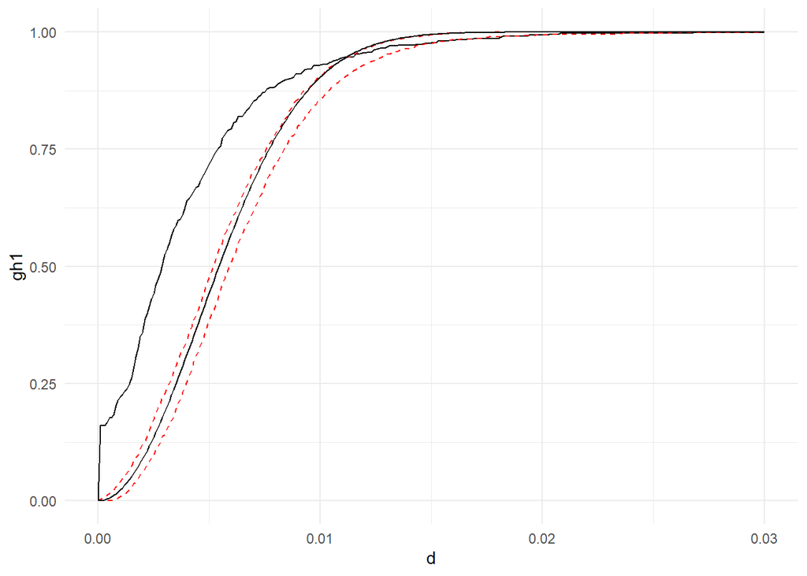

```
##
##  Chi-squared test of CSR using quadrat counts
##
## data:  nval
## X2 = 1421.3, df = 24, p-value < 2.2e-16
## alternative hypothesis: two.sided
##
## Quadrats: 5 by 5 grid of tiles
```

2. Faça uma estimação por kernel da intensidade de crimes na cidade de Nova York, considere diferentes valores para a bandwidth.

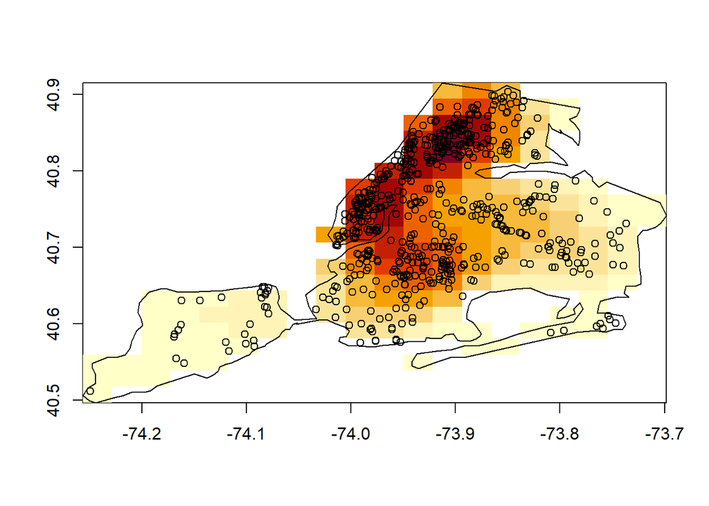

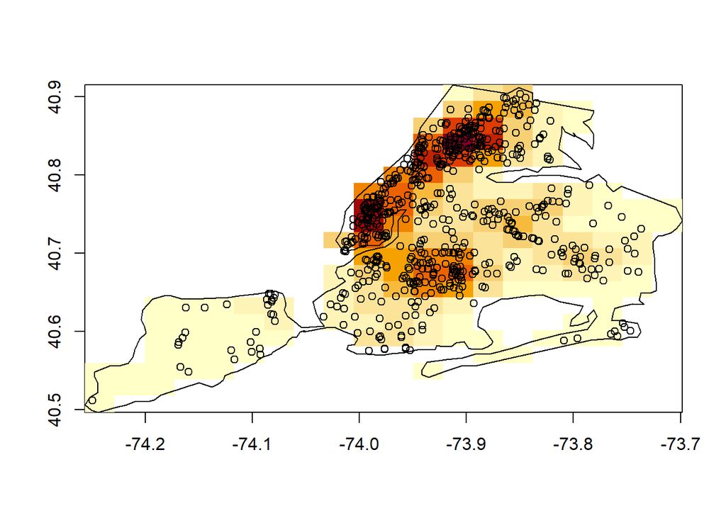

3. Faça a análise de dois tipos de crimes conjuntamente.

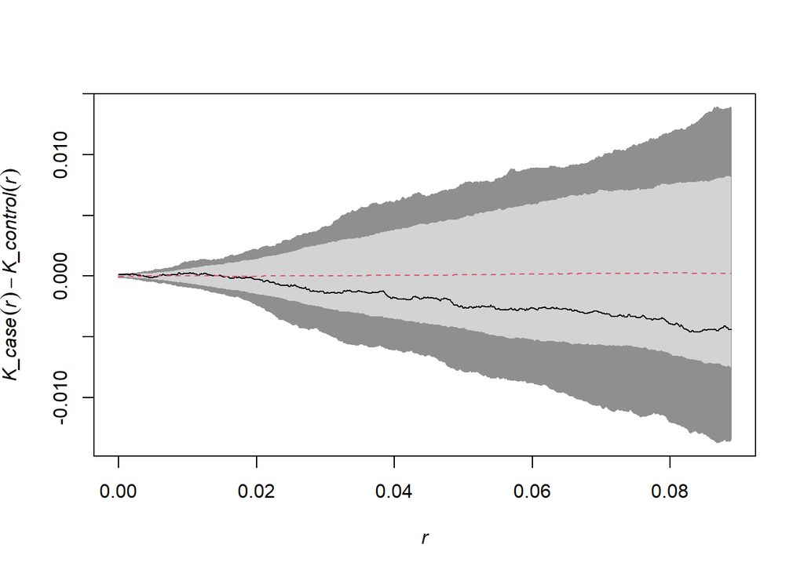

```
## The p-value for the global test is 0.775
```

### Questão 2

O banco de dados a ser analisado é do departamento de polícia da Filadélfia e contêm dados de vítimas de armas de fogo, com informações demográficas e localização dos casos. Uma introdução ao banco e informações sobre obtenção dos dados está disponível no link: https://www.r-bloggers.com/2021/01/visualizing-geospatial-data-in-r-part-3-making-interactive-maps-with-leaflet/?utm_source=feedburner&utm_medium=email&utm_campaign=Feed%3A+RBloggers+%28R+bloggers%29.

Para esse exercício, só considere os dados pontuais, a informação da área não será utilizada.

1. Faça um gráfico dos casos de vítimas de armas de fogo, esse gráfico deve conter apenas a informação pontual desses dados.

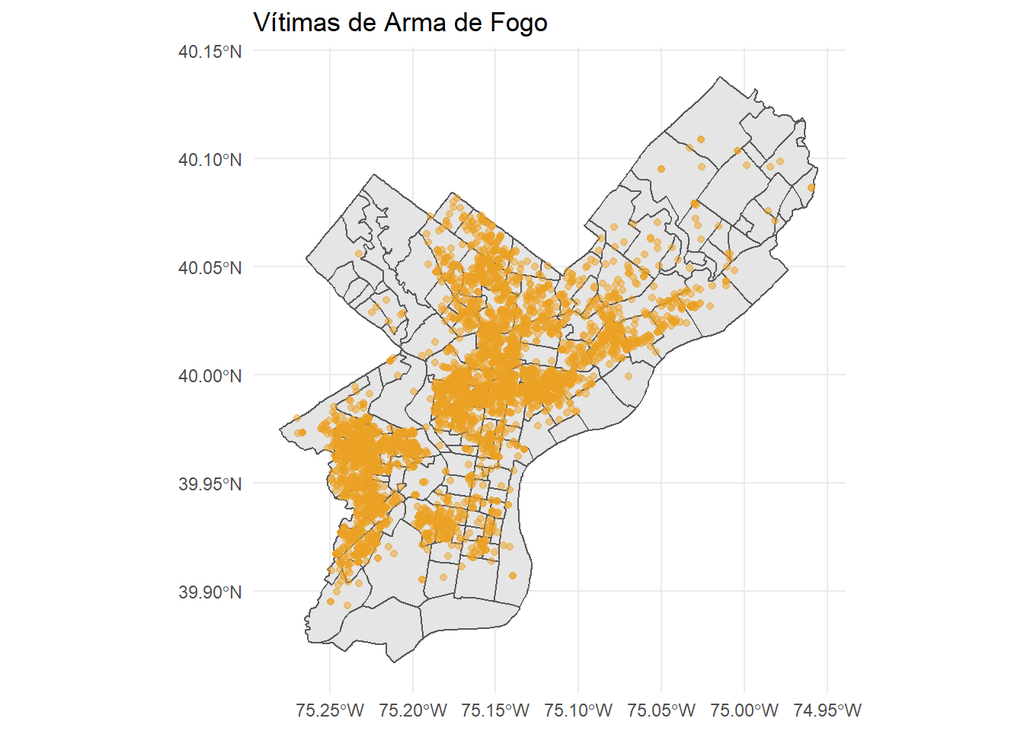

```r
ggplot()+
geom_sf(data = neighborhoods)+
geom_sf(data = shootings, col = "#eba123", alpha = 0.5)+
theme_minimal()+
ggtitle("Vítimas de Arma de Fogo")
```

2. Refaça o gráfico acima, só com os pontos referentes à vitímas fatais.

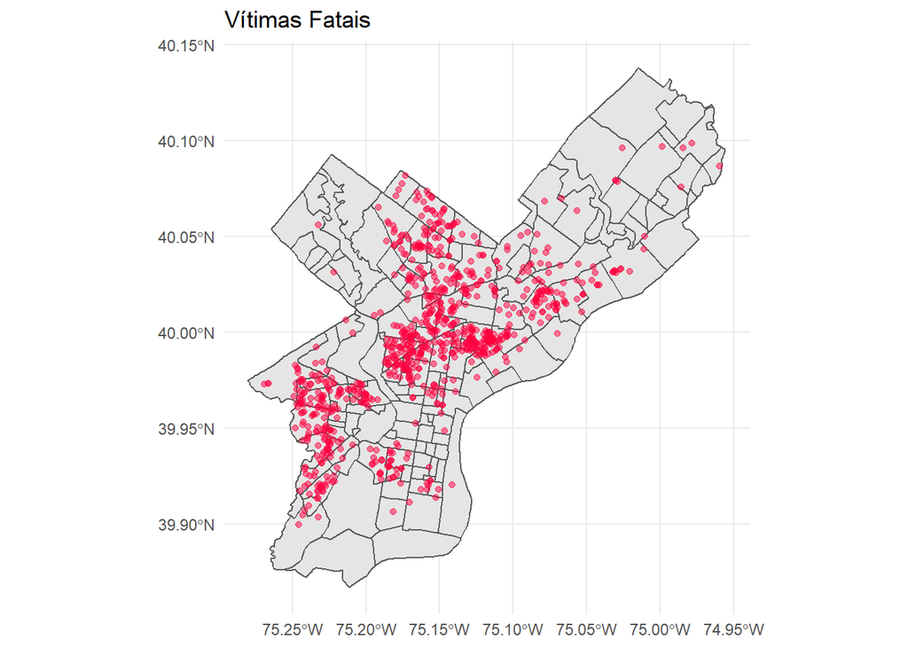

```r
fatal = shootings %>%
filter(fatal == 1)

ggplot()+
geom_sf(data = neighborhoods)+
geom_sf(data = fatal, col = "#ff003e", alpha = 0.5)+
theme_minimal()+
ggtitle("Vítimas Fatais")
```

3. Avalie se os crimes podem ser considerados como um processo de poisson homogêneo, considere somente o ano de 2021 na sua análise.

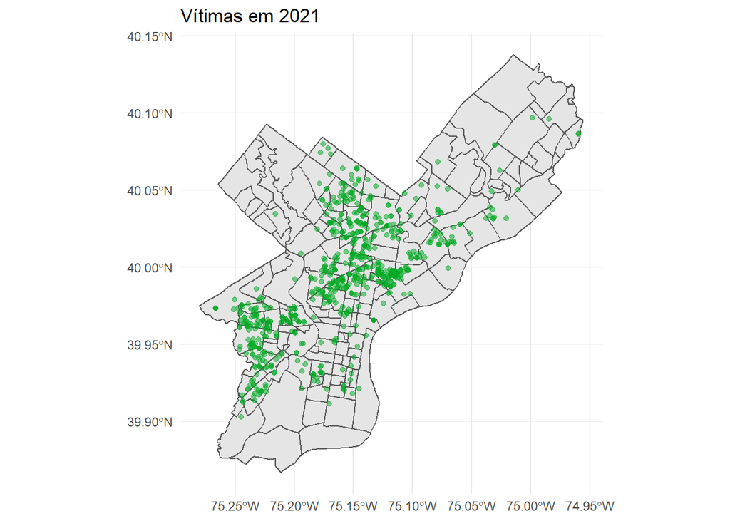

```r
y21 = shootings %>%
  filter(year == 2021)

ggplot() +
    geom_sf(data = neighborhoods) +
    geom_sf(data = y21, col = "#00aa22", alpha = 0.5) +
    theme_minimal() +
    ggtitle("Vítimas em 2021")
```

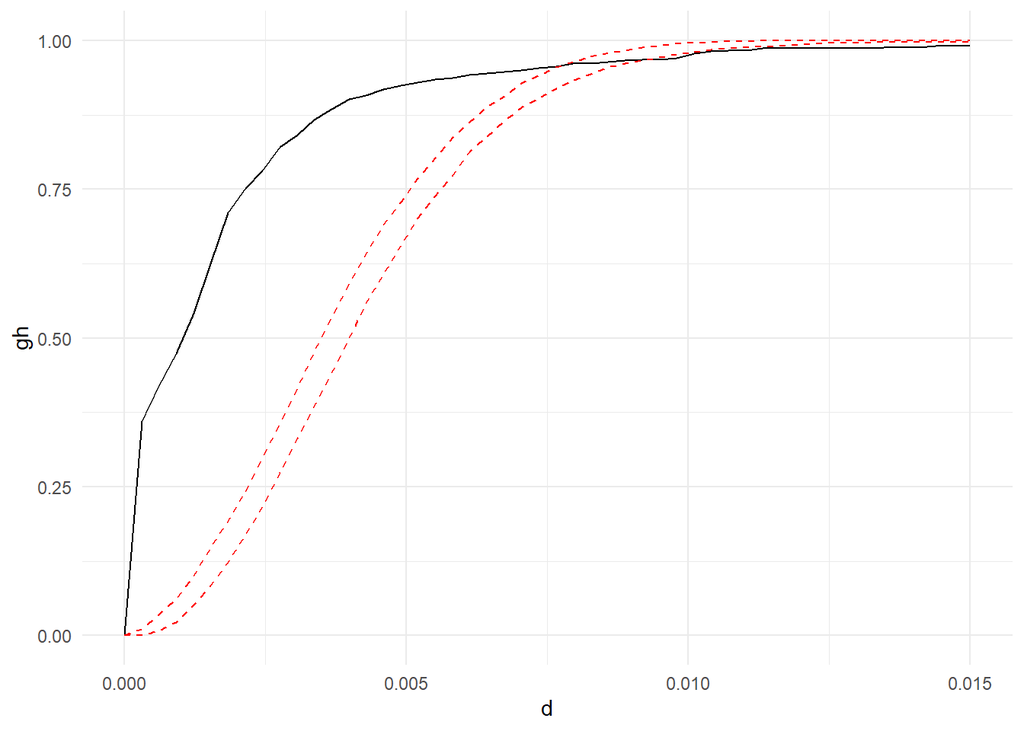

```r
y21_spdf = as_Spatial(y21)
phil_spdf = as_Spatial(neighborhoods)

d = seq(0, 0.015, length = 50)

gh = Ghat(y21_spdf@coords, s = d)

philadelphia <- read_csv("philadelphia.csv",
                         col_types = cols(X1 = col_skip())) %>% as.points()

envred = fcn.Ghatenv(y21_spdf@coords, philadelphia, s = d, nsim = 200,
                     quiet = T)

ggplot() +
    geom_line(aes(d, gh)) +
    geom_line(aes(d, envred$lower), col = "red", lty = 2) +
    geom_line(aes(d, envred$upper), col = "red", lty = 2) +
    theme_minimal()
```

Perceba que no gráfico de envelopes acima, a linha preta (que representa a função G do nosso processo) se localiza fora das bandas de confiança geradas, portanto não podemos considerar o processo acima como um processo de Poisson homogêneo.

4. Para o ano de 2021, compare os casos de vítimas fatais e não fatais, elas possuem o mesmo padrão espacial?

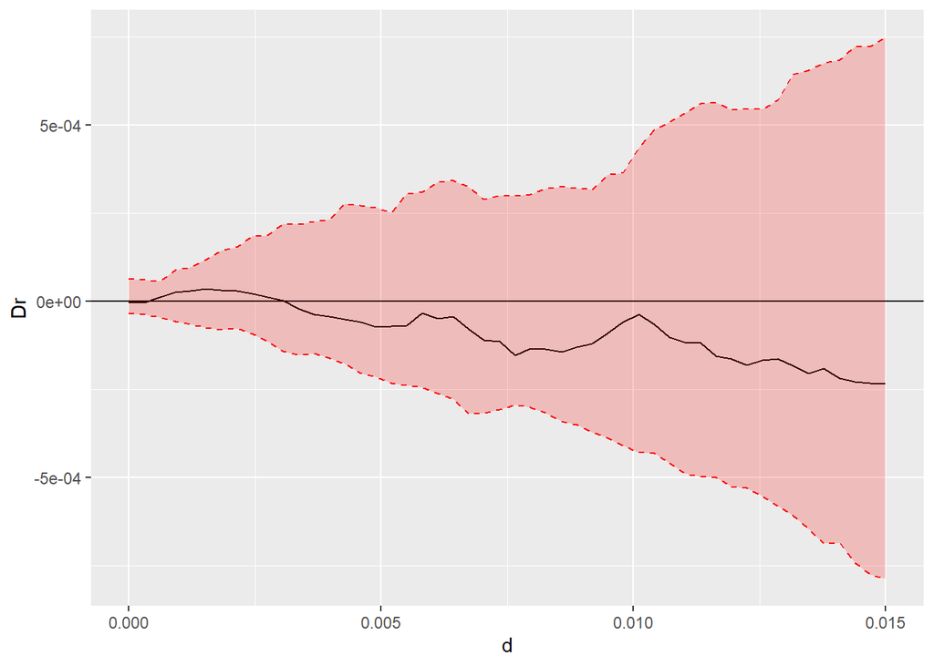

```r
y21_f = y21 %>%
    filter(fatal == 1)

y21_f = as_Spatial(y21_f)


y21_nf = y21 %>%
    filter(fatal == 0)

y21_nf = as_Spatial(y21_nf)


k1 <- khat(y21_f@coords, philadelphia, d)
k2 <- khat(y21_nf@coords, philadelphia, d)


Dr <- k1 - k2

env2 = Kenv.label(y21_f@coords,
                  y21_nf@coords,
                  philadelphia, 200,
                  d, quiet = T)


ggplot() +
    geom_line(aes(d, Dr)) +
    geom_hline(yintercept = 0) +
    geom_line(aes(d, env2$lower), col = "red", lty = 2) +
    geom_line(aes(d, env2$upper), col = "red", lty = 2) +
    geom_ribbon(aes(
        x = d,
        ymin = env2$lower,
        ymax = env2$upper
    ),
    alpha = 0.2,
    fill = "red")
```

É claro ver que, de acordo com a combinação das estatísticas K para igualdade de distribuições, os dois grupos seguem um mesmo padrão espacial.

5. Para o ano de 2021, compare os casos da raça branca e outras, elas possuem o mesmo padrão espacial? Faça os gráficos com cada um desses grupos.

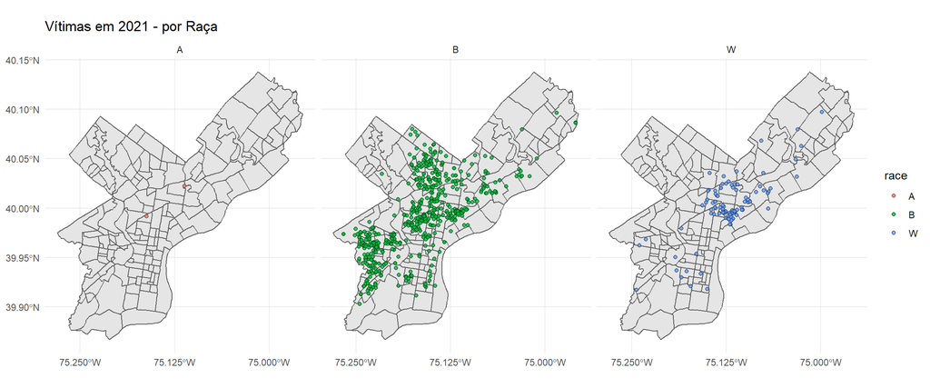

```r
y21_W = y21 %>%
    filter(race == "W") %>%
    as_Spatial


y21_NW = y21 %>%
    filter(race != "W") %>%
    as_Spatial

ggplot() +
    geom_sf(data = neighborhoods) +
    geom_sf(
        aes(fill = race),
        data = y21,
        alpha = 0.8,
        shape = 21,
        col = "black"
    ) +
    theme_minimal() +
    ggtitle("Vítimas em 2021 - por Raça") +
    facet_wrap( ~ race, nrow = 1) +
    scale_x_continuous(breaks = seq(-74.5, -75.5, by = -.125))
```

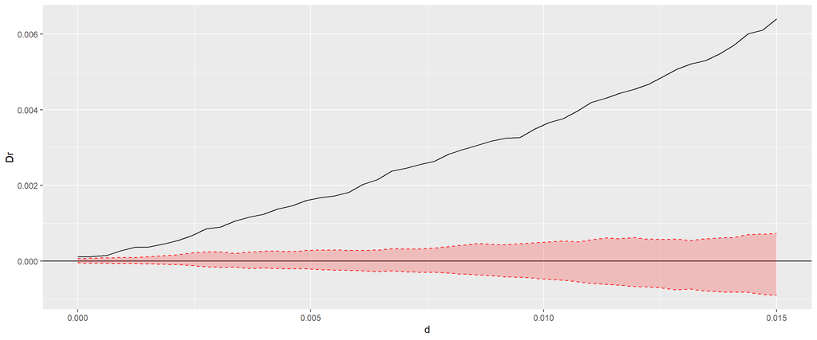

```r
k1 <- khat(y21_W@coords, philadelphia, d)
k2 <- khat(y21_NW@coords, philadelphia, d)


Dr <- k1 - k2

env4 = Kenv.label(y21_W@coords,
                  y21_NW@coords,
                  philadelphia, 200,
                  d, quiet = T)


ggplot() +
    geom_line(aes(d, Dr)) +
    geom_hline(yintercept = 0) +
    geom_line(aes(d, env4$lower), col = "red", lty = 2) +
    geom_line(aes(d, env4$upper), col = "red", lty = 2) +
    geom_ribbon(aes(
        x = d,
        ymin = env4$lower,
        ymax = env4$upper
    ),
    alpha = 0.2,
    fill = "red")
```

O plot da estatística K conjunta demonstra uma diferença nítida entre as diferentes raças. Nos dados, as raças são codificadas da seguinte forma: A para asiáticos, B para afro-americanos / negros e W para brancos. A primeira e maior diferença notada visualmente é justo a incidência de casos entre as raças, largamente superior para o grupo B. Além disso, podemos dizer que a região central concentra o maior número de casos, tendo ocorrências independente de grupo.

| race | n | ratio |
| --- | --- | --- |
| A | 2 | 0.27% |
| B | 623 | 84.42% |
| W | 113 | 15.31% |

6. Faça um mapa de kernel somente com as vítimas de mais de 50 anos e compare com o mapa das vítimas de entre 18 e 30 anos. Elas possuem o mesmo padrão espacial?

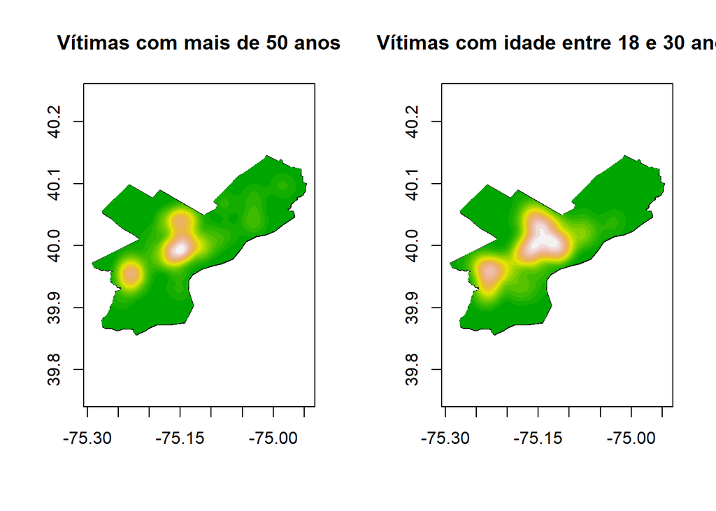

```r
y21_50p <- y21 %>%
  filter(as.integer(y21$age) >= 50)%>%
  as_Spatial()

y21_1830 <- y21 %>%
    filter(as.integer(y21$age) >= 18 & as.integer(y21$age) <= 30)%>%
  as_Spatial()

# kernel2d calls goes here
par(mfrow = c(1,2))

k_50p = kernel2d(y21_50p@coords, philadelphia, h0 = 0.025, nx = 500, ny = 500, quiet = T)
polymap(philadelphia)
image(k_50p, add = T, col=terrain.colors(20))
title(main = "Vítimas com mais de 50 anos")


k_30m = kernel2d(y21_1830@coords, philadelphia, h0 = 0.025, nx = 500, ny = 500, quiet = T)
polymap(philadelphia)
image(k_30m, add = T, col=terrain.colors(20))
title(main = "Vítimas com idade entre 18 e 30 anos")
```

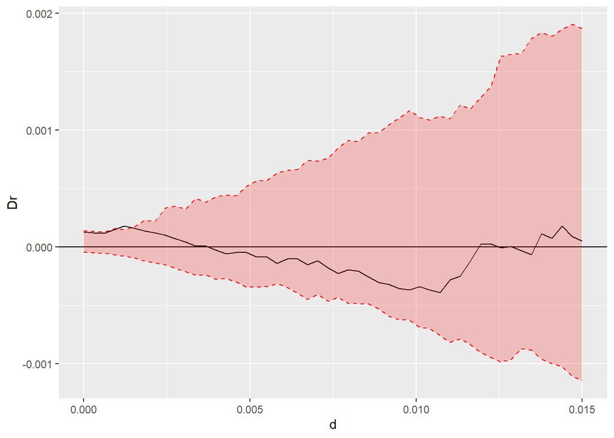

```r
k1 <- khat(y21_50p@coords, philadelphia, d)
k2 <- khat(y21_1830@coords, philadelphia, d)


Dr <- k1 - k2

env3 = Kenv.label(y21_50p@coords,
                  y21_1830@coords,
                  philadelphia, 200,
                  d, quiet = T)


ggplot() +
    geom_line(aes(d, Dr)) +
    geom_hline(yintercept = 0) +
    geom_line(aes(d, env3$lower), col = "red", lty = 2) +
    geom_line(aes(d, env3$upper), col = "red", lty = 2) +
    geom_ribbon(aes(
        x = d,
        ymin = env3$lower,
        ymax = env3$upper
    ),
    alpha = 0.2,
    fill = "red")
```

Como podemos ver pelo segundo gráfico, a linha de $D_r$ se encontra dentro das bandas de confiança geradas por simulação de MC. Portanto, não temos razões para dizer que os dois grupos não possuem o mesmo padrão espacial.